# US Flight Delay and Cancellation Trends in 2019

## Preliminary Wrangling

This dataset reports flights in the United States, including arrival and departure delays, cancellations, and reasons for delays and cancellations, for the whole year of 2019.

```python
# import all packages and set plots to be embedded inline
import numpy as np
import pandas as pd
import matplotlib.pyplot as plt
import seaborn as sb

%matplotlib inline
```

```python
# Gather all months individually
jan2019 = pd.read_csv('jan2019_ONTIME_REPORTING.csv')
feb2019 = pd.read_csv('feb2019_ONTIME_REPORTING.csv')
mar2019 = pd.read_csv('mar2019_ONTIME_REPORTING.csv')
apr2019 = pd.read_csv('apr2019_ONTIME_REPORTING.csv')
may2019 = pd.read_csv('may2019_ONTIME_REPORTING.csv')
jun2019 = pd.read_csv('jun2019_ONTIME_REPORTING.csv')
jul2019 = pd.read_csv('jul2019_ONTIME_REPORTING.csv')
aug2019 = pd.read_csv('aug2019_ONTIME_REPORTING.csv')
sep2019 = pd.read_csv('sep2019_ONTIME_REPORTING.csv')
oct2019 = pd.read_csv('oct2019_ONTIME_REPORTING.csv')
nov2019 = pd.read_csv('nov2019_ONTIME_REPORTING.csv')
dec2019 = pd.read_csv('dec2019_ONTIME_REPORTING.csv')
```

I wanted to gather more years' worth of data, but each month of data was so large that I had to limit how many months I gathered. I was interested in trends across seasons, so I wanted to have all months for at least one year. I felt that to be fair, if I included another year, I should include as many months as the first year, which would have made my dataset way too slow to process on my computer. So, even though I started off by including years other than 2019, I decided to just explore the most recent year's data.

```python
jan2019.head()
```

|  | YEAR | MONTH | DAY_OF_MONTH | DAY_OF_WEEK | OP_UNIQUE_CARRIER | TAIL_NUM | OP_CARRIER_FL_NUM | ORIGIN_AIRPORT_ID | DEST_AIRPORT_ID | CRS_DEP_TIME | ... | CRS_ELAPSED_TIME | ACTUAL_ELAPSED_TIME | AIR_TIME | DISTANCE | CARRIER_DELAY | WEATHER_DELAY | NAS_DELAY | SECURITY_DELAY | LATE_AIRCRAFT_DELAY | Unnamed: 29 |
| --- | --- | --- | --- | --- | --- | --- | --- | --- | --- | --- | --- | --- | --- | --- | --- | --- | --- | --- | --- | --- | --- |
| 0 | 2019 | 1 | 3 | 4 | 9E | N195PQ | 5121 | 15412 | 10397 | 1140 | ... | 70.0 | 70.0 | 36.0 | 152.0 | 0.0 | 0.0 | 0.0 | 0.0 | 25.0 | NaN |
| 1 | 2019 | 1 | 4 | 5 | 9E | N919XJ | 5121 | 15412 | 10397 | 1140 | ... | 70.0 | 82.0 | 38.0 | 152.0 | 0.0 | 0.0 | 12.0 | 0.0 | 70.0 | NaN |
| 2 | 2019 | 1 | 5 | 6 | 9E | N316PQ | 5122 | 10397 | 14783 | 950 | ... | 121.0 | 107.0 | 84.0 | 563.0 | NaN | NaN | NaN | NaN | NaN | NaN |
| 3 | 2019 | 1 | 6 | 7 | 9E | N325PQ | 5122 | 10397 | 14783 | 950 | ... | 123.0 | 104.0 | 85.0 | 563.0 | NaN | NaN | NaN | NaN | NaN | NaN |
| 4 | 2019 | 1 | 7 | 1 | 9E | N904XJ | 5122 | 10397 | 14783 | 950 | ... | 123.0 | 117.0 | 88.0 | 563.0 | NaN | NaN | NaN | NaN | NaN | NaN |

5 rows × 30 columns

```python
# Join all 2019 months
frames = [jan2019, feb2019, mar2019, apr2019, may2019, jun2019, jul2019, aug2019, sep2019, oct2019, nov2019, dec2019]
flights2019 = pd.concat(frames, ignore_index=True)
```

```python
flights2019.shape
```

```
(7453087, 30)
```

```python
flights2019.drop('Unnamed: 29',axis=1,inplace=True) # I dont' know what this column is
```

```python
flights2019.info()
```

```
<class 'pandas.core.frame.DataFrame'>
RangeIndex: 7453087 entries, 0 to 7453086
Data columns (total 29 columns):
YEAR                   int64
MONTH                  int64
DAY_OF_MONTH           int64
DAY_OF_WEEK            int64
OP_UNIQUE_CARRIER      object
TAIL_NUM               object
OP_CARRIER_FL_NUM      int64
ORIGIN_AIRPORT_ID      int64
DEST_AIRPORT_ID        int64
CRS_DEP_TIME           int64
DEP_TIME               float64
DEP_DELAY              float64
TAXI_OUT               float64
TAXI_IN                float64
CRS_ARR_TIME           int64
ARR_TIME               float64
ARR_DELAY              float64
CANCELLED              float64
CANCELLATION_CODE      object
DIVERTED               float64
CRS_ELAPSED_TIME       float64
ACTUAL_ELAPSED_TIME    float64
AIR_TIME               float64
DISTANCE               float64
CARRIER_DELAY          float64
WEATHER_DELAY          float64
NAS_DELAY              float64
SECURITY_DELAY         float64
LATE_AIRCRAFT_DELAY    float64
dtypes: float64(17), int64(9), object(3)
memory usage: 1.6+ GB
```

```python
# These are not needed for my analysis and will help speed up code execution
flights2019.drop(['YEAR','TAIL_NUM','OP_CARRIER_FL_NUM','TAXI_OUT','TAXI_IN','DIVERTED','CRS_ELAPSED_TIME','ACTUAL_ELAPSED_TIME','AIR_TIME','DISTANCE'],axis=1,inplace=True)
```

```python
pd.options.display.max_info_rows = 8000000 # So I can see null value counts
flights2019.info()
```

```
<class 'pandas.core.frame.DataFrame'>
RangeIndex: 7453087 entries, 0 to 7453086
Data columns (total 19 columns):
MONTH                  7453087 non-null int64
DAY_OF_MONTH           7453087 non-null int64
DAY_OF_WEEK            7453087 non-null int64
OP_UNIQUE_CARRIER      7453087 non-null object
ORIGIN_AIRPORT_ID      7453087 non-null int64
DEST_AIRPORT_ID        7453087 non-null int64
CRS_DEP_TIME           7453087 non-null int64
DEP_TIME               7319086 non-null float64
DEP_DELAY              7319067 non-null float64
CRS_ARR_TIME           7453087 non-null int64
ARR_TIME               7311374 non-null float64
ARR_DELAY              7296064 non-null float64
CANCELLED              7453087 non-null float64
CANCELLATION_CODE      138807 non-null object
CARRIER_DELAY          1425709 non-null float64
WEATHER_DELAY          1425709 non-null float64
NAS_DELAY              1425709 non-null float64
SECURITY_DELAY         1425709 non-null float64
LATE_AIRCRAFT_DELAY    1425709 non-null float64
dtypes: float64(10), int64(7), object(2)
memory usage: 1.1+ GB
```

I'd like to look more into the way the various delay reasons columns are structured, since there are many null values.

```python
flights2019.loc[flights2019.ARR_DELAY.isnull() & flights2019.CANCELLATION_CODE.isnull() & ~flights2019.ARR_TIME.isnull(),['CRS_DEP_TIME','DEP_TIME','CRS_ARR_TIME','ARR_TIME','ARR_DELAY','CANCELLATION_CODE']]
```

|  | CRS_DEP_TIME | DEP_TIME | CRS_ARR_TIME | ARR_TIME | ARR_DELAY | CANCELLATION_CODE |
| --- | --- | --- | --- | --- | --- | --- |
| 3123 | 715 | 714.0 | 1100 | 1406.0 | NaN | NaN |
| 6523 | 1520 | 1530.0 | 1740 | 1846.0 | NaN | NaN |
| 7627 | 1225 | 1233.0 | 1415 | 1614.0 | NaN | NaN |
| 9124 | 1325 | 1319.0 | 1435 | 1720.0 | NaN | NaN |
| 10056 | 1250 | 1253.0 | 1405 | 1602.0 | NaN | NaN |
| ... | ... | ... | ... | ... | ... | ... |
| 7437785 | 1110 | 1107.0 | 1202 | 1423.0 | NaN | NaN |
| 7438243 | 2002 | 2024.0 | 2133 | 2250.0 | NaN | NaN |
| 7438894 | 1932 | 2017.0 | 2234 | 38.0 | NaN | NaN |
| 7439116 | 1552 | 1552.0 | 1739 | 2156.0 | NaN | NaN |
| 7439208 | 1646 | 1720.0 | 1726 | 2008.0 | NaN | NaN |

15310 rows × 6 columns

Most cases where the arrival delay is null is when the flight is cancelled. However, there are a few cases when there is no cancellation. Since we can't know just from the time how long the flight was delayed (could be over 24 hours without knowing arrival date), let's delete those rows. There aren't many anyway.

```python
null_delay = flights2019[flights2019.ARR_DELAY.isnull() & flights2019.CANCELLATION_CODE.isnull()] # arrival delay not given, but flight not cancelled
flights2019.drop(null_delay.index,inplace=True)
flights2019.shape
```

```
(7434871, 19)
```

```python
# Check
flights2019.loc[flights2019.ARR_DELAY.isnull() & flights2019.CANCELLATION_CODE.isnull(),['CRS_DEP_TIME','DEP_TIME','CRS_ARR_TIME','ARR_TIME','ARR_DELAY','CANCELLATION_CODE']] # should be empty - good
```

|  | CRS_DEP_TIME | DEP_TIME | CRS_ARR_TIME | ARR_TIME | ARR_DELAY | CANCELLATION_CODE |
| --- | --- | --- | --- | --- | --- | --- |

```python
# for val in flights2019.ARR_TIME.values:
#     try:
#          pd.to_datetime(val, format='%H%M')
#     except:
#         print("Error received at {}".format(val))
# print("All done!")
```

```python
# flights2019[flights2019['ARR_TIME']=='2400']
```

```python
flights2019.info()
```

```
<class 'pandas.core.frame.DataFrame'>
Int64Index: 7434871 entries, 0 to 7453086
Data columns (total 19 columns):
MONTH                  7434871 non-null int64
DAY_OF_MONTH           7434871 non-null int64
DAY_OF_WEEK            7434871 non-null int64
OP_UNIQUE_CARRIER      7434871 non-null object
ORIGIN_AIRPORT_ID      7434871 non-null int64
DEST_AIRPORT_ID        7434871 non-null int64
CRS_DEP_TIME           7434871 non-null int64
DEP_TIME               7300870 non-null float64
DEP_DELAY              7300851 non-null float64
CRS_ARR_TIME           7434871 non-null int64
ARR_TIME               7296064 non-null float64
ARR_DELAY              7296064 non-null float64
CANCELLED              7434871 non-null float64
CANCELLATION_CODE      138807 non-null object
CARRIER_DELAY          1425709 non-null float64
WEATHER_DELAY          1425709 non-null float64
NAS_DELAY              1425709 non-null float64
SECURITY_DELAY         1425709 non-null float64
LATE_AIRCRAFT_DELAY    1425709 non-null float64
dtypes: float64(10), int64(7), object(2)
memory usage: 1.1+ GB
```

```python
flights2019[flights2019.CANCELLED==True].shape
```

```
(138807, 19)
```

Try to find out specifically how the delay reason columns are populated.

```python
has_delay_reason = flights2019[~flights2019.CARRIER_DELAY.isnull()]
has_delay_reason.describe()
```

|  | MONTH | DAY_OF_MONTH | DAY_OF_WEEK | ORIGIN_AIRPORT_ID | DEST_AIRPORT_ID | CRS_DEP_TIME | DEP_TIME | DEP_DELAY | CRS_ARR_TIME | ARR_TIME | ARR_DELAY | CANCELLED | CARRIER_DELAY | WEATHER_DELAY | NAS_DELAY | SECURITY_DELAY | LATE_AIRCRAFT_DELAY |
| --- | --- | --- | --- | --- | --- | --- | --- | --- | --- | --- | --- | --- | --- | --- | --- | --- | --- |
| count | 1.425709e+06 | 1.425709e+06 | 1.425709e+06 | 1.425709e+06 | 1.425709e+06 | 1.425709e+06 | 1.425709e+06 | 1.425709e+06 | 1.425709e+06 | 1.425709e+06 | 1.425709e+06 | 1425709.0 | 1.425709e+06 | 1.425709e+06 | 1.425709e+06 | 1.425709e+06 | 1.425709e+06 |
| mean | 5.888531e+00 | 1.565236e+01 | 3.976946e+00 | 1.262174e+04 | 1.267979e+04 | 1.459896e+03 | 1.515784e+03 | 6.352162e+01 | 1.608320e+03 | 1.544843e+03 | 6.815820e+01 | 0.0 | 2.081361e+01 | 3.649112e+00 | 1.656451e+01 | 9.539815e-02 | 2.703557e+01 |
| std | 3.572111e+00 | 8.806711e+00 | 1.953179e+00 | 1.492555e+03 | 1.505631e+03 | 4.650875e+02 | 5.043426e+02 | 9.182702e+01 | 5.214136e+02 | 6.348963e+02 | 8.895164e+01 | 0.0 | 6.580156e+01 | 3.171589e+01 | 3.838370e+01 | 3.312482e+00 | 5.271803e+01 |
| min | 1.000000e+00 | 1.000000e+00 | 1.000000e+00 | 1.013500e+04 | 1.013500e+04 | 1.000000e+00 | 1.000000e+00 | -3.400000e+01 | 1.000000e+00 | 1.000000e+00 | 1.500000e+01 | 0.0 | 0.000000e+00 | 0.000000e+00 | 0.000000e+00 | 0.000000e+00 | 0.000000e+00 |
| 25% | 3.000000e+00 | 8.000000e+00 | 2.000000e+00 | 1.129200e+04 | 1.129200e+04 | 1.108000e+03 | 1.143000e+03 | 1.800000e+01 | 1.248000e+03 | 1.210000e+03 | 2.400000e+01 | 0.0 | 0.000000e+00 | 0.000000e+00 | 0.000000e+00 | 0.000000e+00 | 0.000000e+00 |
| 50% | 6.000000e+00 | 1.600000e+01 | 4.000000e+00 | 1.247800e+04 | 1.288900e+04 | 1.517000e+03 | 1.600000e+03 | 4.000000e+01 | 1.709000e+03 | 1.707000e+03 | 4.000000e+01 | 0.0 | 0.000000e+00 | 0.000000e+00 | 3.000000e+00 | 0.000000e+00 | 3.000000e+00 |
| 75% | 8.000000e+00 | 2.300000e+01 | 6.000000e+00 | 1.393000e+04 | 1.393100e+04 | 1.831000e+03 | 1.925000e+03 | 7.900000e+01 | 2.028000e+03 | 2.038000e+03 | 7.900000e+01 | 0.0 | 1.700000e+01 | 0.000000e+00 | 2.000000e+01 | 0.000000e+00 | 3.300000e+01 |
| max | 1.200000e+01 | 3.100000e+01 | 7.000000e+00 | 1.686900e+04 | 1.686900e+04 | 2.359000e+03 | 2.400000e+03 | 2.710000e+03 | 2.400000e+03 | 2.400000e+03 | 2.695000e+03 | 0.0 | 2.695000e+03 | 1.847000e+03 | 1.741000e+03 | 1.078000e+03 | 2.206000e+03 |

```python
has_delay_no_reason = (flights2019.DEP_DELAY>30) & (flights2019.CARRIER_DELAY.isnull())
flights2019.loc[has_delay_no_reason,['DEP_DELAY','ARR_DELAY','CARRIER_DELAY','WEATHER_DELAY','NAS_DELAY','SECURITY_DELAY','LATE_AIRCRAFT_DELAY']]
```

|  | DEP_DELAY | ARR_DELAY | CARRIER_DELAY | WEATHER_DELAY | NAS_DELAY | SECURITY_DELAY | LATE_AIRCRAFT_DELAY |
| --- | --- | --- | --- | --- | --- | --- | --- |
| 467 | 31.0 | 10.0 | NaN | NaN | NaN | NaN | NaN |
| 964 | 31.0 | 11.0 | NaN | NaN | NaN | NaN | NaN |
| 1581 | 31.0 | 5.0 | NaN | NaN | NaN | NaN | NaN |
| 1677 | 34.0 | 11.0 | NaN | NaN | NaN | NaN | NaN |
| 3051 | 32.0 | 11.0 | NaN | NaN | NaN | NaN | NaN |
| ... | ... | ... | ... | ... | ... | ... | ... |
| 7451671 | 32.0 | 8.0 | NaN | NaN | NaN | NaN | NaN |
| 7451921 | 33.0 | 1.0 | NaN | NaN | NaN | NaN | NaN |
| 7452333 | 31.0 | 12.0 | NaN | NaN | NaN | NaN | NaN |
| 7452991 | 34.0 | -6.0 | NaN | NaN | NaN | NaN | NaN |
| 7452994 | 34.0 | 4.0 | NaN | NaN | NaN | NaN | NaN |

25064 rows × 7 columns

```python
has_arr_delay = (flights2019.ARR_DELAY>15)
flights2019.loc[has_arr_delay,['DEP_DELAY','ARR_DELAY','CARRIER_DELAY','WEATHER_DELAY','NAS_DELAY','SECURITY_DELAY','LATE_AIRCRAFT_DELAY']].sample(20)
```

|  | DEP_DELAY | ARR_DELAY | CARRIER_DELAY | WEATHER_DELAY | NAS_DELAY | SECURITY_DELAY | LATE_AIRCRAFT_DELAY |
| --- | --- | --- | --- | --- | --- | --- | --- |
| 4619250 | 37.0 | 65.0 | 0.0 | 0.0 | 33.0 | 0.0 | 32.0 |
| 1910645 | 37.0 | 23.0 | 0.0 | 0.0 | 0.0 | 0.0 | 23.0 |
| 3977467 | 19.0 | 27.0 | 19.0 | 0.0 | 8.0 | 0.0 | 0.0 |
| 3588733 | 52.0 | 52.0 | 0.0 | 0.0 | 0.0 | 0.0 | 52.0 |
| 3486840 | 26.0 | 19.0 | 13.0 | 0.0 | 0.0 | 0.0 | 6.0 |
| 1362126 | 7.0 | 37.0 | 7.0 | 0.0 | 30.0 | 0.0 | 0.0 |
| 6647856 | 8.0 | 19.0 | 8.0 | 0.0 | 11.0 | 0.0 | 0.0 |
| 3071329 | 27.0 | 56.0 | 27.0 | 0.0 | 29.0 | 0.0 | 0.0 |
| 1080345 | 52.0 | 39.0 | 0.0 | 0.0 | 0.0 | 0.0 | 39.0 |
| 5565496 | -6.0 | 21.0 | 0.0 | 0.0 | 21.0 | 0.0 | 0.0 |
| 3862552 | 34.0 | 24.0 | 0.0 | 0.0 | 0.0 | 0.0 | 24.0 |
| 7449280 | 1222.0 | 1204.0 | 276.0 | 0.0 | 0.0 | 0.0 | 928.0 |
| 1435174 | 307.0 | 293.0 | 0.0 | 0.0 | 0.0 | 0.0 | 293.0 |
| 6409029 | 64.0 | 49.0 | 49.0 | 0.0 | 0.0 | 0.0 | 0.0 |
| 2812642 | 78.0 | 74.0 | 21.0 | 0.0 | 0.0 | 0.0 | 53.0 |
| 1946197 | 2.0 | 55.0 | 2.0 | 0.0 | 53.0 | 0.0 | 0.0 |
| 3765866 | 101.0 | 95.0 | 95.0 | 0.0 | 0.0 | 0.0 | 0.0 |
| 2326213 | 81.0 | 69.0 | 0.0 | 0.0 | 0.0 | 0.0 | 69.0 |
| 3469602 | 314.0 | 300.0 | 0.0 | 0.0 | 76.0 | 0.0 | 224.0 |
| 4336445 | 120.0 | 124.0 | 81.0 | 0.0 | 4.0 | 0.0 | 39.0 |

I'm trying to figure out when there is no reason given for the delay. It seems that it's always given if the arrival delay is at least 15 minutes. On the other hand, length of departure delays doesn't seem to affect whether there are nulls.

### What is the structure of your dataset?

My dataset has 7434871 datapoints each representing a flight in 2019. There are 19 variables (after deleting ones that are not of interest) describing each flight, however there are many null values for causes of delay (last 5 columns). Departure/arrival times/delays also have some null values, as well as many in the cancellations column. Some of these nulls just indicate that a flight was cancelled/never departed. In general, most variables are numeric, but cancellation code and carrier code are strings.

### What is/are the main feature(s) of interest in your dataset?

I'm interested in learning what variables are correlated with delays and cancellations. I'm also interested in the reasons for cancellations and for delays.

### What features in the dataset do you think will help support your investigation into your feature(s) of interest?

I think certain airports may experience more delays than others, maybe even certain origin-desitination pairs. I think scheduled time of flight, and possibly day of the week, will also contribute.

## Univariate Exploration

I'll start by looking at the distribution of the first main variable of interest, which is delay. Let's look at both departure and arrival delay, but I'll probably mostly consider just arrival delay, since that's what seems to matter more, and the two are often related.

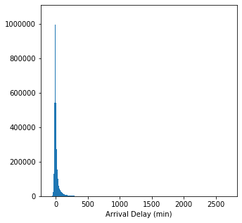

```python
# start with a standard-scaled plot
binsize = 5
bins = np.arange(flights2019.ARR_DELAY.min(), flights2019.ARR_DELAY.max()+binsize, binsize)

plt.figure(figsize=[5, 5])
plt.hist(data = flights2019, x = 'ARR_DELAY', bins = bins)
plt.xlabel('Arrival Delay (min)')
# plt.ylim(0,1000)
plt.show()
```

```python
flights2019.ARR_DELAY.describe()
```

```
count    7.296064e+06
mean     5.693533e+00
std      5.093781e+01
min     -9.400000e+01
25%     -1.500000e+01
50%     -6.000000e+00
75%      8.000000e+00
max      2.695000e+03
Name: ARR_DELAY, dtype: float64
```

```python
# Filter to only top 95% of the data to visualize better:

flights2019_top95 = flights2019[flights2019.ARR_DELAY < flights2019.ARR_DELAY.quantile(.95)]
```

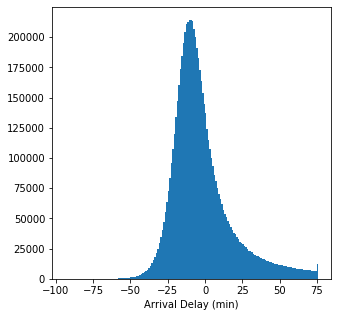

```python
binsize = 1
bins = np.arange(flights2019_top95.ARR_DELAY.min(), flights2019_top95.ARR_DELAY.max()+binsize, binsize)

plt.figure(figsize=[5, 5])
plt.hist(data = flights2019_top95, x = 'ARR_DELAY', bins = bins)
plt.xlabel('Arrival Delay (min)')
# plt.ylim(0,1000)
plt.show()
```

```python
flights2019[flights2019.ARR_DELAY<0].ARR_DELAY.min()
```

```
-94.0
```

```python
flights2019.ARR_DELAY.describe()
```

```
count    7.296064e+06
mean     5.693533e+00
std      5.093781e+01
min     -9.400000e+01
25%     -1.500000e+01
50%     -6.000000e+00
75%      8.000000e+00
max      2.695000e+03
Name: ARR_DELAY, dtype: float64
```

There appears to be at least one outlier in the arrival time data. Explore further to see if they're valid points, especially because the tail goes out past 2500 min, which is almost 42 hours, or nearly 2 full days.

```python
late_flights = flights2019.ARR_DELAY>1000
flights2019.loc[late_flights,['MONTH','DAY_OF_MONTH','ARR_DELAY','DEP_DELAY']].sample(20)
```

|  | MONTH | DAY_OF_MONTH | ARR_DELAY | DEP_DELAY |
| --- | --- | --- | --- | --- |
| 3996685 | 1 | 7 | 1248.0 | 1263.0 |
| 2622203 | 5 | 10 | 1175.0 | 1167.0 |
| 2838758 | 5 | 7 | 1194.0 | 1191.0 |
| 7306357 | 12 | 13 | 1056.0 | 1055.0 |
| 3311014 | 6 | 9 | 1274.0 | 1274.0 |
| 4546158 | 8 | 28 | 1164.0 | 1170.0 |
| 4195103 | 1 | 21 | 1071.0 | 1072.0 |
| 4661558 | 8 | 19 | 1185.0 | 1201.0 |
| 108491 | 1 | 3 | 1167.0 | 1166.0 |
| 4136870 | 1 | 5 | 1638.0 | 1651.0 |
| 6815505 | 10 | 22 | 1020.0 | 1036.0 |
| 6620372 | 10 | 6 | 1001.0 | 1016.0 |
| 3261640 | 6 | 17 | 1131.0 | 1129.0 |
| 5375384 | 8 | 19 | 1127.0 | 1141.0 |
| 4345681 | 8 | 18 | 1099.0 | 1121.0 |
| 5231340 | 8 | 7 | 1123.0 | 1128.0 |
| 4933267 | 8 | 14 | 1219.0 | 1237.0 |
| 5030601 | 8 | 10 | 1232.0 | 1239.0 |
| 6876453 | 12 | 16 | 1021.0 | 984.0 |
| 1110218 | 2 | 6 | 1364.0 | 1324.0 |

The arrival delays of > 1000 min have consistent departure delay, so these are probably valid points. Check out even longer delays.

```python
late_flights = flights2019.ARR_DELAY>1500
flights2019.loc[late_flights,['MONTH','DAY_OF_MONTH','ARR_DELAY','DEP_DELAY']].MONTH.value_counts()
```

```
10    22
12    20
3     20
8     16
2     12
1      8
6      7
5      6
Name: MONTH, dtype: int64
```

1500 minutes is already longer than a day, but still possible, especially in winter when there are snowstorms.

```python
late_flights = flights2019.ARR_DELAY>2000
flights2019.loc[late_flights,['MONTH','DAY_OF_MONTH','ARR_DELAY','DEP_DELAY','CARRIER_DELAY','WEATHER_DELAY','NAS_DELAY','SECURITY_DELAY','LATE_AIRCRAFT_DELAY']]
```

|  | MONTH | DAY_OF_MONTH | ARR_DELAY | DEP_DELAY | CARRIER_DELAY | WEATHER_DELAY | NAS_DELAY | SECURITY_DELAY | LATE_AIRCRAFT_DELAY |
| --- | --- | --- | --- | --- | --- | --- | --- | --- | --- |
| 789029 | 2 | 7 | 2050.0 | 2064.0 | 968.0 | 0.0 | 0.0 | 0.0 | 1082.0 |
| 789346 | 2 | 17 | 2649.0 | 2672.0 | 2592.0 | 0.0 | 0.0 | 0.0 | 57.0 |
| 791629 | 2 | 8 | 2206.0 | 2209.0 | 0.0 | 0.0 | 0.0 | 0.0 | 2206.0 |
| 3466202 | 6 | 10 | 2041.0 | 2058.0 | 2041.0 | 0.0 | 0.0 | 0.0 | 0.0 |
| 5618820 | 10 | 30 | 2034.0 | 2036.0 | 24.0 | 0.0 | 0.0 | 0.0 | 2010.0 |
| 6254834 | 10 | 30 | 2034.0 | 2036.0 | 24.0 | 0.0 | 0.0 | 0.0 | 2010.0 |
| 7047520 | 12 | 12 | 2695.0 | 2710.0 | 2695.0 | 0.0 | 0.0 | 0.0 | 0.0 |

It does seem unusual that a plane would be almost 2 days delayed, but there are few cases, and it doesn't seem like the numbers were mistyped, so leave them as valid.

If I don't filter for the top 95% of the data, there's a long tail in the distribution, so let's put it on a log scale instead.

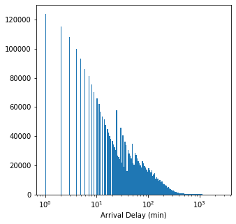

```python
# Change to log scale
log_binsize = 0.02
bins = 10 ** np.arange(0, np.log10(flights2019.ARR_DELAY.max())+log_binsize, log_binsize)

plt.figure(figsize=[5, 5])
plt.hist(data = flights2019, x = 'ARR_DELAY', bins = bins)
plt.xscale('log')
# plt.xticks([500, 1e3, 2e3, 5e3, 1e4, 2e4], [500, '1k', '2k', '5k', '10k', '20k'])
plt.xlabel('Arrival Delay (min)')
plt.show()
```

Plotting arrival delay on a log scale is not so helpful, since we can't plot negative delays (early arrivals). However, we can see the values a little better now. Depending on the bin size, we get a small spike somewhere between 10 and 100 min, but in general, the delay count falls off quite rapidly with increasing delay.

Perhaps a better visual is still the normal scale, but displayed with only the top 95% of the data.

```python
flights2019.ARR_DELAY.mode()
```

```
0   -10.0
dtype: float64
```

It turns out that the arrival delay distribution is unimodal and heavily right skewed, with the peak delay actually just below 0 at 10 minutes *early*.

Since the arrival delay distribution is not so easy to deal with, let's look at adding a variable for simply "delayed" or "not delayed", and also one for breaking the delay into descrete bins.

```python
# Consider cancelled flights "delayed"
flights2019['DELAYED'] = (flights2019.ARR_DELAY>0) | (flights2019.CANCELLED==1)
```

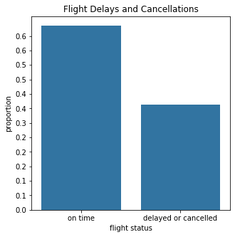

```python
plt.figure(figsize=(5,5))

n_points = flights2019.shape[0]
max_count = flights2019.DELAYED.value_counts().max()
max_prop = max_count / n_points

tick_props = np.arange(0, max_prop, .05)
# tick_props = np.arange(0, 1.1, .1)
tick_names = ['{:0.1f}'.format(v) for v in tick_props]

default_color = sb.color_palette()[0]
g = sb.countplot(data = flights2019, x = 'DELAYED', color = default_color);
plt.yticks(tick_props*n_points, tick_names)
plt.ylabel('proportion')
plt.xlabel('flight status');
g.set(xticklabels=['on time','delayed or cancelled']);
plt.title('Flight Delays and Cancellations');
```

```python
flights2019[flights2019.DELAYED].shape[0]/flights2019.shape[0]
```

```
0.36417296278576994
```

Over 1/3 of flights are delayed or cancelled, which is quite high. However, this includes flights arriving even 1 minute late. So let's break it down more.

```python
flights2019['DELAY_BIN'] = ""
ontime = (flights2019.ARR_DELAY<=0)
# upto_5min = ((flights2019.ARR_DELAY>0) & (flights2019.ARR_DELAY<=5))
# upto_1hr = ((flights2019.ARR_DELAY>5) & (flights2019.ARR_DELAY<=60))
upto_1hr = ((flights2019.ARR_DELAY>0) & (flights2019.ARR_DELAY<=60))
over_1hr = (flights2019.ARR_DELAY>60)
cancelled = flights2019.CANCELLED==1

flights2019.loc[ontime,'DELAY_BIN'] = 'on time'
# flights2019.loc[upto_5min,'DELAY_BIN'] = '5 min late'
flights2019.loc[upto_1hr,'DELAY_BIN'] = '1 hour late'
flights2019.loc[over_1hr,'DELAY_BIN'] = 'over 1 hour late'
flights2019.loc[cancelled,'DELAY_BIN'] = 'cancelled'
```

I considered breaking the delay into various different bins, thinking that +/- 5 min didn't mean anything, or that maybe we're interested if a flight is not just on-time, but early. Ultimately though, I chose this simple breakdown that nobody can argue with.

```python
# delay_order = ['on time','5 min late', '1 hour late', 'over 1 hour late', 'cancelled']
delay_order = ['on time', '1 hour late', 'over 1 hour late', 'cancelled']
ordered_delay = pd.api.types.CategoricalDtype(ordered=True,categories=delay_order)
flights2019['DELAY_BIN'] = flights2019['DELAY_BIN'].astype(ordered_delay)
```

```python
flights2019.DELAY_BIN.value_counts()
```

```
on time             4727292
1 hour late         2084566
over 1 hour late     484206
cancelled            138807
Name: DELAY_BIN, dtype: int64
```

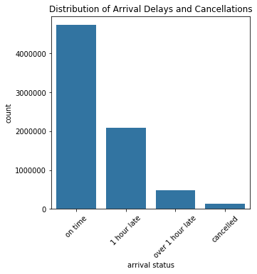

```python
plt.figure(figsize=(5,5))
default_color = sb.color_palette()[0]

delay_bin_order = flights2019.DELAY_BIN.value_counts().index

g = sb.countplot(data = flights2019, x = 'DELAY_BIN', color = default_color);

plt.xlabel('arrival status');
plt.xticks(rotation=45);
plt.title('Distribution of Arrival Delays and Cancellations');
```

From delays, shift to looking at cancellations.

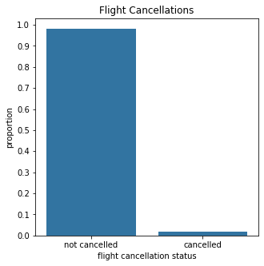

```python
plt.figure(figsize=(5,5))

# This time, look at percentages instead of total counts
n_points = flights2019.shape[0]
max_count = flights2019.CANCELLED.value_counts().max()
max_prop = max_count / n_points

# tick_props = np.arange(0, max_prop, .05)
tick_props = np.arange(0, 1.1, .1)
tick_names = ['{:0.1f}'.format(v) for v in tick_props]

g = sb.countplot(data = flights2019, x = 'CANCELLED', color = default_color);
plt.yticks(tick_props*n_points, tick_names)
plt.ylabel('proportion')
plt.xlabel('flight cancellation status');
g.set(xticklabels=['not cancelled','cancelled']);
plt.title('Flight Cancellations');
```

```python
flights2019[flights2019.CANCELLED==1].shape[0] #138,807
flights2019[flights2019.CANCELLED==1].shape[0]/flights2019.shape[0]
```

```
0.018669725406130114
```

Less than 2% of flights were cancelled in 2019.

I will now shift to looking at the other variables. First I will investigate the distribution of flights each day of the week.

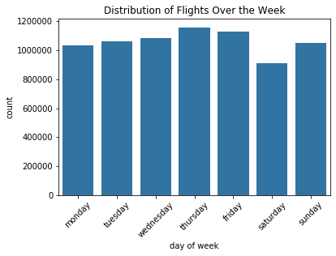

```python
default_color = sb.color_palette()[0]
g = sb.countplot(data = flights2019, x = 'DAY_OF_WEEK', color = default_color);

plt.xlabel('day of week');
g.set(xticklabels=['monday','tuesday','wednesday','thursday','friday','saturday','sunday']);
plt.xticks(rotation=45);
plt.title('Distribution of Flights Over the Week');
```

This is a pretty uniform distribution, nothing unusual. Saturday is a bit lower than other days, but this make sense to me.

Let's see if there's any more variability in flights for different seasons. First, we have to make a new variable column corresponding to season.

```python
flights2019.insert(2,"SEASON",'fillin')
```

```python
winter = (flights2019.MONTH==12) | (flights2019.MONTH==1) | (flights2019.MONTH==2)
spring = (flights2019.MONTH==3) | (flights2019.MONTH==4) | (flights2019.MONTH==5)
summer = (flights2019.MONTH==6) | (flights2019.MONTH==7) | (flights2019.MONTH==8)
fall = (flights2019.MONTH==9) | (flights2019.MONTH==10) | (flights2019.MONTH==11)

flights2019.loc[winter,'SEASON'] = 'winter'
flights2019.loc[spring,'SEASON'] = 'spring'
flights2019.loc[summer,'SEASON'] = 'summer'
flights2019.loc[fall,'SEASON'] = 'fall'
```

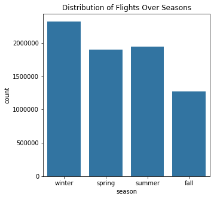

```python
plt.figure(figsize=(5,5))

g = sb.countplot(data = flights2019, x = 'SEASON', color = default_color);

plt.xlabel('season');
# plt.xticks(rotation=45);
plt.title('Distribution of Flights Over Seasons');
```

I'm actually surprised that winter has the most flights, and fall has the fewest. Summer and spring are pretty even.

Let's take a closer look, just to make sure the data looks valid.

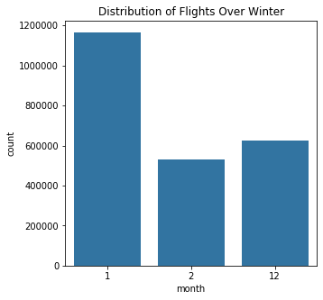

```python
flights2019_winter = flights2019[flights2019['SEASON'] == 'winter']
plt.figure(figsize=(5,5))

g = sb.countplot(data = flights2019_winter, x = 'MONTH', color = default_color);

plt.xlabel('month');
# plt.xticks(rotation=45);
plt.title('Distribution of Flights Over Winter');
```

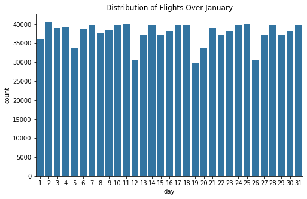

```python
flights2019_jan = flights2019_winter[flights2019['MONTH'] == 1]
plt.figure(figsize=(8,5))

g = sb.countplot(data = flights2019_jan, x = 'DAY_OF_MONTH', color = default_color);

plt.xlabel('day');
plt.title('Distribution of Flights Over January');
```

Ok, so winter seems to have a lot of flights, in particular January. But when I look closer, it seems they're distributed periodically over January, so I think this is valid, whatever the reason.

Now let's look at another categorical variable that might have a more uneven distribution.

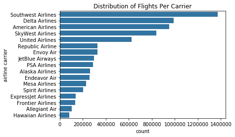

```python
# flights2019.OP_UNIQUE_CARRIER
airline_dict = {'9E': 'Endeavor Air', 'WN': 'Southwest Airlines', 'G4': 'Allegiant Air', 'OH': 'PSA Airlines', 'B6': 'JetBlue Airways', 'NK': 'Spirit Airlines', 'OO': 'SkyWest Airlines', 'AA': 'American Airlines', 'MQ': 'Envoy Air', 'UA': 'United Airlines', 'DL': 'Delta Airlines', 'YV': 'Mesa Airlines', 'YX': 'Republic Airline', 'AS': 'Alaska Airlines', 'F9': 'Frontier Airlines', 'HA': 'Hawaiian Airlines', 'EV': 'ExpressJet Airlines'}

gen_order = flights2019.OP_UNIQUE_CARRIER.value_counts().index
g = sb.countplot(data = flights2019, y = 'OP_UNIQUE_CARRIER', color = default_color, order = gen_order);

y_labels = [] #create an empty list to store the labels
for key in gen_order:
    y_labels.append(airline_dict[key]) #store each label in the correct order

plt.ylabel('airline carrier');
g.set(yticklabels=y_labels);
# plt.xticks(rotation=90);
plt.title('Distribution of Flights Per Carrier');
```

It appears that Southwest has the most flights in this 2019 dataset, followed by other popular airlines. The distribution justifies taking the top 5 airlines if I don't want to use all these carriers for further correlations and analyses.

```python
top_airlines = ['WN','DL','AA','OO','UA']
flights2019_top_airlines = flights2019[flights2019.OP_UNIQUE_CARRIER.isin(top_airlines)]
```

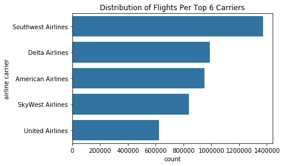

```python
airline_order = flights2019_top_airlines.OP_UNIQUE_CARRIER.value_counts().index
g = sb.countplot(data = flights2019, y = 'OP_UNIQUE_CARRIER', color = default_color, order = airline_order);

y_labels = [] #create an empty list to store the labels
for key in airline_order:
    y_labels.append(airline_dict[key]) #store each label in the correct order

plt.ylabel('airline carrier');
g.set(yticklabels=y_labels);
# plt.xticks(rotation=90);
plt.title('Distribution of Flights Per Top 6 Carriers');
```

Next, I will look at the distribution of flights into select destination airports.

```python
flights2019.DEST_AIRPORT_ID.value_counts()[:10]
```

```
10397    397286
13930    338957
11298    302699
11292    250566
11057    235856
12892    221588
12266    180290
14107    178074
14771    173426
12953    172608
Name: DEST_AIRPORT_ID, dtype: int64
```

There are many, so choose those with over 200,000 flights, or the top 6.

```python
# Since the airports are encoded based on id number, make a dictionary to airport codes, which more people understand
airport_dict = {10397: 'ATL', 13930: 'ORD', 11298: 'DFW', 11292: 'DEN', 11057: 'CLT', 12892: 'LAX'}
```

```python
top_airports = list(airport_dict.keys())
top_airports
```

```
[10397, 13930, 11298, 11292, 11057, 12892]
```

```python
flights2019_top_airports = flights2019[flights2019.DEST_AIRPORT_ID.isin(top_airports)]
```

```python
flights2019_top_airports.sample(10)
```

|  | MONTH | DAY_OF_MONTH | SEASON | DAY_OF_WEEK | OP_UNIQUE_CARRIER | ORIGIN_AIRPORT_ID | DEST_AIRPORT_ID | CRS_DEP_TIME | DEP_TIME | DEP_DELAY | ... | ARR_DELAY | CANCELLED | CANCELLATION_CODE | CARRIER_DELAY | WEATHER_DELAY | NAS_DELAY | SECURITY_DELAY | LATE_AIRCRAFT_DELAY | DELAYED | DELAY_BIN |
| --- | --- | --- | --- | --- | --- | --- | --- | --- | --- | --- | --- | --- | --- | --- | --- | --- | --- | --- | --- | --- | --- |
| 896096 | 2 | 18 | winter | 1 | EV | 15370 | 13930 | 610 | 608.0 | -2.0 | ... | -10.0 | 0.0 | NaN | NaN | NaN | NaN | NaN | NaN | False | on time |
| 5418563 | 8 | 20 | summer | 2 | AA | 12953 | 11298 | 629 | 625.0 | -4.0 | ... | -31.0 | 0.0 | NaN | NaN | NaN | NaN | NaN | NaN | False | on time |
| 512087 | 1 | 2 | winter | 3 | OH | 12323 | 11057 | 1250 | 1241.0 | -9.0 | ... | -11.0 | 0.0 | NaN | NaN | NaN | NaN | NaN | NaN | False | on time |
| 1971890 | 3 | 25 | spring | 1 | DL | 12448 | 10397 | 740 | 740.0 | 0.0 | ... | 7.0 | 0.0 | NaN | NaN | NaN | NaN | NaN | NaN | True | 1 hour late |
| 3191236 | 6 | 30 | summer | 7 | AS | 14057 | 12892 | 700 | 657.0 | -3.0 | ... | 10.0 | 0.0 | NaN | NaN | NaN | NaN | NaN | NaN | True | 1 hour late |
| 4715145 | 8 | 19 | summer | 1 | OO | 12891 | 11298 | 1357 | 1354.0 | -3.0 | ... | -16.0 | 0.0 | NaN | NaN | NaN | NaN | NaN | NaN | False | on time |
| 7369763 | 12 | 15 | winter | 7 | DL | 12173 | 10397 | 1650 | 1643.0 | -7.0 | ... | -35.0 | 0.0 | NaN | NaN | NaN | NaN | NaN | NaN | False | on time |
| 513632 | 1 | 7 | winter | 1 | OH | 13795 | 11057 | 1916 | 1908.0 | -8.0 | ... | 12.0 | 0.0 | NaN | NaN | NaN | NaN | NaN | NaN | True | 1 hour late |
| 6803723 | 10 | 5 | fall | 6 | AA | 13204 | 13930 | 1633 | 1629.0 | -4.0 | ... | -25.0 | 0.0 | NaN | NaN | NaN | NaN | NaN | NaN | False | on time |
| 7175423 | 12 | 16 | winter | 1 | DL | 13232 | 10397 | 1049 | 1042.0 | -7.0 | ... | -8.0 | 0.0 | NaN | NaN | NaN | NaN | NaN | NaN | False | on time |

10 rows × 22 columns

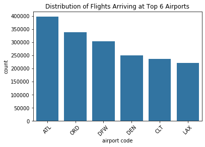

```python
gen_order = flights2019_top_airports.DEST_AIRPORT_ID.value_counts().index
g = sb.countplot(data = flights2019_top_airports, x = 'DEST_AIRPORT_ID', color = default_color, order = gen_order);

x_labels = [] #create an empty list to store the labels
for key in gen_order:
    x_labels.append(airport_dict[key]) #store each label in the correct order

plt.xlabel('airport code');
g.set(xticklabels=x_labels);
plt.xticks(rotation=45);
plt.title('Distribution of Flights Arriving at Top 6 Airports');
```

Now look at the distribution of flight departure times. To make things easier, let's just divide the times into hour bins. So, we need to first need to convert times to datetime format, and extract the hour into a new column variable.

```python
flights2019.CRS_DEP_TIME = flights2019.CRS_DEP_TIME.astype(str).str.pad(4, fillchar='0') # convert time to string and pad with leading 0 so that we have HHMM format
```

```python
# Convert to datetime so we can extract hour later
flights2019.CRS_DEP_TIME = pd.to_datetime(flights2019.CRS_DEP_TIME,format='%H%M')
flights2019.CRS_DEP_TIME = pd.to_datetime(flights2019.CRS_DEP_TIME.dt.strftime('%H:%M'))
```

```python
# Extract hour and check
flights2019['DEP_HOUR'] = flights2019['CRS_DEP_TIME'].dt.hour
flights2019.loc[:,['CRS_DEP_TIME', 'DEP_HOUR']].sample(10)
```

|  | CRS_DEP_TIME | DEP_HOUR |
| --- | --- | --- |
| 6564546 | 2020-04-03 17:09:00 | 17 |
| 6484664 | 2020-04-03 06:00:00 | 6 |
| 4319196 | 2020-04-03 15:40:00 | 15 |
| 3241537 | 2020-04-03 09:41:00 | 9 |
| 2034757 | 2020-04-03 20:10:00 | 20 |
| 6966095 | 2020-04-03 08:19:00 | 8 |
| 5990112 | 2020-04-03 07:00:00 | 7 |
| 962604 | 2020-04-03 08:29:00 | 8 |
| 879183 | 2020-04-03 16:35:00 | 16 |
| 2293917 | 2020-04-03 16:40:00 | 16 |

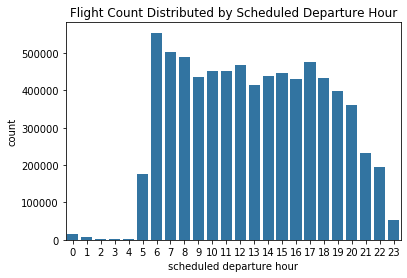

```python
default_color = sb.color_palette()[0]

g = sb.countplot(data = flights2019, x = 'DEP_HOUR', color = default_color);

plt.xlabel('scheduled departure hour');
plt.ylabel('count');
plt.title('Flight Count Distributed by Scheduled Departure Hour');
```

Looks like the 6 o'clock hour is the most popular time for flights. The remainder of the flights wave, with other peaks at noon and 5pm. Most flight are between 5am and 11pm.

Maybe I'd like to look at comparing just am and pm flights. Do this next.

```python
flights2019.insert(11,"DEP_TIME_OF_DAY",'fillin')
```

```python
am = flights2019.CRS_DEP_TIME<'12:00:00'
pm = flights2019.CRS_DEP_TIME>='12:00:00'


flights2019.loc[am,'DEP_TIME_OF_DAY'] = 'am'
flights2019.loc[pm,'DEP_TIME_OF_DAY'] = 'pm'
```

```python
flights2019[['CRS_DEP_TIME','DEP_TIME_OF_DAY']].sample(10)
```

|  | CRS_DEP_TIME | DEP_TIME_OF_DAY |
| --- | --- | --- |
| 3914610 | 2020-04-03 08:06:00 | am |
| 2024562 | 2020-04-03 05:30:00 | am |
| 4192217 | 2020-04-03 12:16:00 | pm |
| 4521601 | 2020-04-03 06:15:00 | am |
| 4920424 | 2020-04-03 08:50:00 | am |
| 2683649 | 2020-04-03 12:00:00 | pm |
| 7248624 | 2020-04-03 12:05:00 | pm |
| 2480647 | 2020-04-03 10:25:00 | am |
| 7373784 | 2020-04-03 07:25:00 | am |
| 5340976 | 2020-04-03 23:55:00 | pm |

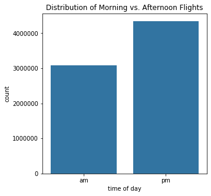

```python
plt.figure(figsize=(5,5))

g = sb.countplot(data = flights2019, x = 'DEP_TIME_OF_DAY', color = default_color);

plt.xlabel('time of day');
plt.title('Distribution of Morning vs. Afternoon Flights');
```

There's more flights in the afternoon. This makes sense, because there's more waking hours in the afternoon that people are willing to take flights.

Now let's look at cause of delay. The columns corresponding to the delays are only non-null for high enough arrival time delays. However, at least if one of the reason columns is non-null, all of them are.

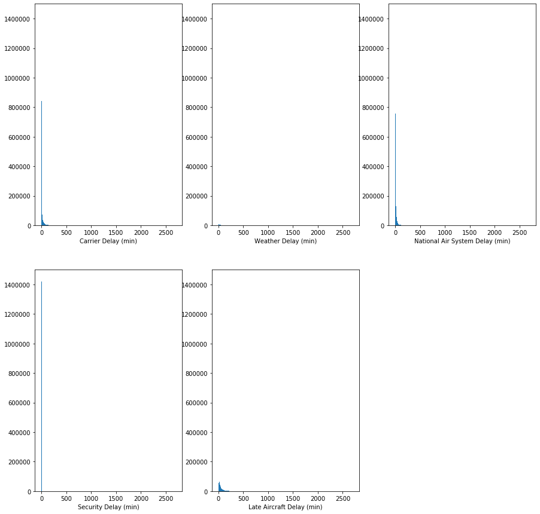

```python
f, axs = plt.subplots(2,3,figsize=(15,15))

plt.subplot(2,3,1)
binsize = 5
max_delay = np.max([flights2019.CARRIER_DELAY.max(), flights2019.WEATHER_DELAY.max(), flights2019.NAS_DELAY.max(), flights2019.SECURITY_DELAY.max(), flights2019.LATE_AIRCRAFT_DELAY.max()])
bins = np.arange(0, max_delay+binsize, binsize) # min will always be 0

plt.hist(data = flights2019, x = 'CARRIER_DELAY', bins = bins)
plt.xlabel('Carrier Delay (min)')
plt.ylim(0,1500000)

plt.subplot(2,3,2)
plt.hist(data = flights2019, x = 'WEATHER_DELAY', bins = bins)
plt.xlabel('Weather Delay (min)')
plt.ylim(0,1500000)

plt.subplot(2,3,3)
plt.hist(data = flights2019, x = 'NAS_DELAY', bins = bins)
plt.xlabel('National Air System Delay (min)')
plt.ylim(0,1500000)

plt.subplot(2,3,4)
plt.hist(data = flights2019, x = 'SECURITY_DELAY', bins = bins)
plt.xlabel('Security Delay (min)')
plt.ylim(0,1500000)

plt.subplot(2,3,5)
plt.hist(data = flights2019, x = 'LATE_AIRCRAFT_DELAY', bins = bins)
plt.xlabel('Late Aircraft Delay (min)')
plt.ylim(0,1500000)

f.delaxes(axs[1][2])
```

These plots are difficult to read, because I wanted to put them all on the same scale. These plots all have the same number of points, corresponding to flights that had a significant delay in one or more of these categories. For the less popular delay reasons though, we have a lot of 0 delays, which requires the y-axis range to be so large that the distribution can't be seen.

Plot again, but this time starting from 10 minute, to eliminate the larger spikes. Also zoom in to up to 1500 minutes.

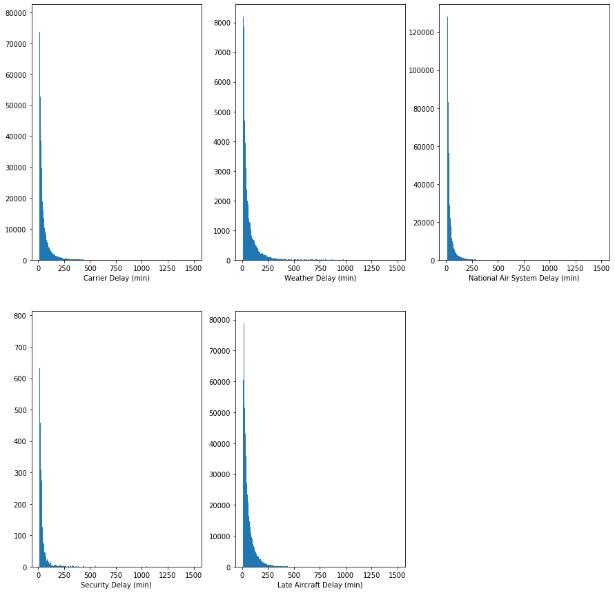

```python
f, axs = plt.subplots(2,3,figsize=(15,15))

plt.subplot(2,3,1)
binsize = 5
max_delay = np.max([flights2019.CARRIER_DELAY.max(), flights2019.WEATHER_DELAY.max(), flights2019.NAS_DELAY.max(), flights2019.SECURITY_DELAY.max(), flights2019.LATE_AIRCRAFT_DELAY.max()])
bins = np.arange(10, 1500+binsize, binsize) # min will always be 0

plt.hist(data = flights2019, x = 'CARRIER_DELAY', bins = bins)
plt.xlabel('Carrier Delay (min)')
# plt.ylim(0,1500000)

plt.subplot(2,3,2)
plt.hist(data = flights2019, x = 'WEATHER_DELAY', bins = bins)
plt.xlabel('Weather Delay (min)')
# plt.ylim(0,1500000)

plt.subplot(2,3,3)
plt.hist(data = flights2019, x = 'NAS_DELAY', bins = bins)
plt.xlabel('National Air System Delay (min)')
# plt.ylim(0,1500000)

plt.subplot(2,3,4)
plt.hist(data = flights2019, x = 'SECURITY_DELAY', bins = bins)
plt.xlabel('Security Delay (min)')
# plt.ylim(0,1500000)

plt.subplot(2,3,5)
plt.hist(data = flights2019, x = 'LATE_AIRCRAFT_DELAY', bins = bins)
plt.xlabel('Late Aircraft Delay (min)')
# plt.ylim(0,1500000)

f.delaxes(axs[1][2])
```

So all of these distributions drops off very rapidly from 0. The longest tail appears to be on the weather delay, though it's still hard to tell with the different y-axis ranges. One thing we can tell from comparing these plots is that there are noticeably fewer non-zero delays due to security (4th plot). This is confirmed by summing down the columns as below.

```python
delay_reasons = flights2019[['CARRIER_DELAY', 'WEATHER_DELAY', 'NAS_DELAY', 'SECURITY_DELAY', 'LATE_AIRCRAFT_DELAY']]
delay_reasons.sum(axis = 0, skipna = True)
```

```
CARRIER_DELAY          29674156.0
WEATHER_DELAY           5202572.0
NAS_DELAY              23616167.0
SECURITY_DELAY           136010.0
LATE_AIRCRAFT_DELAY    38544859.0
dtype: float64
```

Finally, look at reason for cancellations. Every flight that is "cancelled" has a reason.

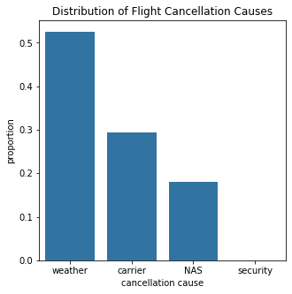

```python
plt.figure(figsize=(5,5))

cancel_dict = {'A': 'carrier', 'B': 'weather', 'C': 'NAS', 'D': 'security'}

n_points = flights2019[flights2019.CANCELLED==1].shape[0]
max_count = flights2019.CANCELLATION_CODE.value_counts().max()
max_prop = max_count / n_points

tick_props = np.arange(0, max_prop, .1)
tick_names = ['{:0.1f}'.format(v) for v in tick_props]

cancel_order = flights2019.CANCELLATION_CODE.value_counts().index
g = sb.countplot(data = flights2019, x = 'CANCELLATION_CODE', color = default_color, order = cancel_order);

cancel_x_labels = [] #create an empty list to store the labels
for key in cancel_order:
    cancel_x_labels.append(cancel_dict[key]) #store each label in the correct order

plt.xlabel('cancellation cause');
g.set(xticklabels=cancel_x_labels);
plt.title('Distribution of Flight Cancellation Causes');

plt.yticks(tick_props*n_points, tick_names)
plt.ylabel('proportion')
```

```python
flights2019.CANCELLATION_CODE.value_counts()
```

```
B    72909
A    40868
C    25015
D       15
Name: CANCELLATION_CODE, dtype: int64
```

Weather is by far the most common cause of flight cancellation, at just over half. Security cancellations are very rare.

### Discuss the distribution(s) of your variable(s) of interest. Were there any unusual points? Did you need to perform any transformations?

The arrival delay distribution is unimodal and heavily right skewed, with the peak delay actually just below 0 at 10 minutes EARLY. With the long tail at higher values, I initially performed a log transformation to plot. This didn't give me any new insights, so I went back to the original plot, but visualized with the top 95% of delay values. I also made another column corresponding to delay bins, which was easier to visualize. That plot was distributed as expected.

The cancellation plot was a boring one, but it also looked at expected, with only a small percentage of total flight cancellations in 2019.

### Of the features you investigated, were there any unusual distributions? Did you perform any operations on the data to tidy, adjust, or change the form of the data? If so, why did you do this?

None of the distributions seemed unusual to me, except the flight count over seasons, which upon further inspection seems valid. The basic shapes of the other variables were expected based on what I understand about US flights.

## Bivariate Exploration

Start off plotting delay against other variables (all of which are categorical).

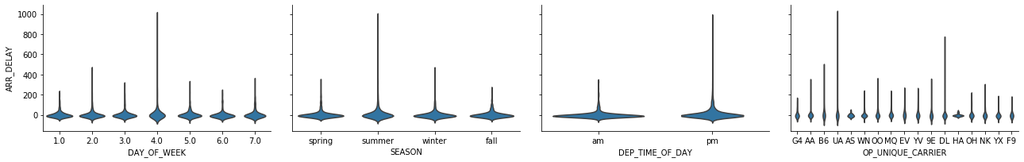

```python
# Plot matrix of delay vs. categorical variables
# Sample to avoid overplotting

samples = np.random.choice(flights2019.shape[0], 2000, replace = False)
flights_samp = flights2019.loc[samples,:]


def boxgrid(x, y, **kwargs):
    """ Quick hack for creating box plots with seaborn's PairGrid. """
    default_color = sb.color_palette()[0]
#     sb.boxplot(x, y, color = default_color);
    sb.violinplot(x, y, color = default_color, inner=None);

plt.figure(figsize = [15, 5]);
g = sb.PairGrid(data = flights_samp, y_vars = ['ARR_DELAY'], x_vars = ['DAY_OF_WEEK','SEASON','DEP_TIME_OF_DAY','OP_UNIQUE_CARRIER'],
                height = 3, aspect = 1.5);
g.map(boxgrid);
plt.show();
```

Redo with only the top 95% of delay values to better see the distribution.

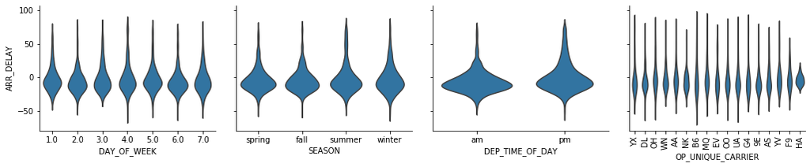

```python
# Redo the top 95% with new columns
flights2019_top95 = flights2019[flights2019.ARR_DELAY < flights2019.ARR_DELAY.quantile(.95)]

samples = np.random.choice(flights2019_top95.shape[0], 2000, replace = False)
flights_top95_samp = flights2019_top95.loc[samples,:]

plt.figure(figsize = [20, 5]);
default_color = sb.color_palette()[0]
g = sb.PairGrid(data=flights_top95_samp, y_vars = ['ARR_DELAY'], x_vars = ['DAY_OF_WEEK','SEASON','DEP_TIME_OF_DAY','OP_UNIQUE_CARRIER'], height = 3, aspect = 1.2);
g.map(sb.violinplot,inner=None, color = default_color);
plt.xticks(rotation=90);
```

Maybe I can get more information from looking at individual box plots.

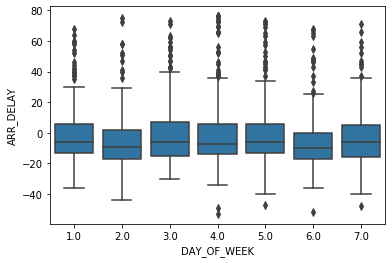

```python
sb.boxplot(data = flights_top95_samp, x = 'DAY_OF_WEEK', y = 'ARR_DELAY', color =  default_color);
```

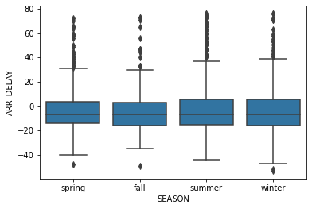

```python
sb.boxplot(data = flights_top95_samp, x = 'SEASON', y = 'ARR_DELAY', color =  default_color);
```

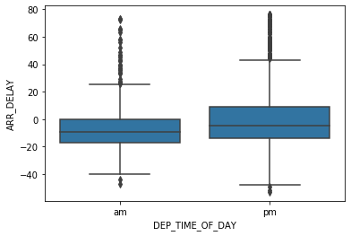

```python
sb.boxplot(data = flights_top95_samp, x = 'DEP_TIME_OF_DAY', y = 'ARR_DELAY', color =  default_color);
```

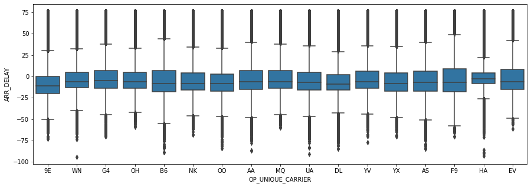

```python
plt.figure(figsize = [15, 5]);
sb.boxplot(data = flights2019_top95, x = 'OP_UNIQUE_CARRIER', y = 'ARR_DELAY', color =  default_color);
```

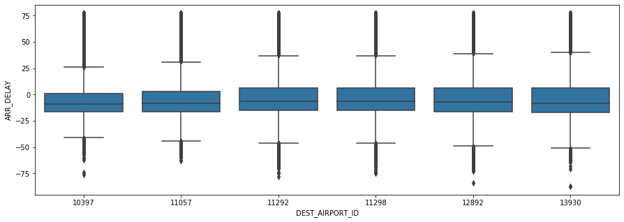

```python
# filter top 95% for flights2019_top_airports
flights2019_top_airports_top95 = flights2019_top_airports[flights2019_top_airports.ARR_DELAY < flights2019_top_airports.ARR_DELAY.quantile(.95)]

plt.figure(figsize = [15, 5]);
sb.boxplot(data = flights2019_top_airports_top95, x = 'DEST_AIRPORT_ID', y = 'ARR_DELAY', color = default_color);
```

This all is not showing me any variations. Let's see if we can get any clearer of a picture by plotting the categorical delay I made earlier, via a clustered bar chart.

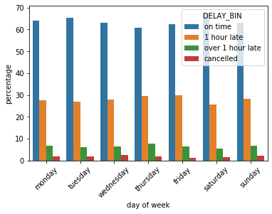

```python
day_of_week_counts = (flights2019.groupby(['DAY_OF_WEEK'])['DELAY_BIN']
                     .value_counts(normalize=True)
                     .rename('percentage')
                     .mul(100)
                     .reset_index()
                     .sort_values('DAY_OF_WEEK'))
p = sb.barplot(x="DAY_OF_WEEK", y="percentage", hue="DELAY_BIN", data=day_of_week_counts)
p.set(xticklabels=['monday','tuesday','wednesday','thursday','friday','saturday','sunday']);
_ = plt.setp(p.get_xticklabels(), rotation=45)  # Rotate labels
plt.xlabel('day of week');
```

This still looks very uniformly spread across all the days of the week.

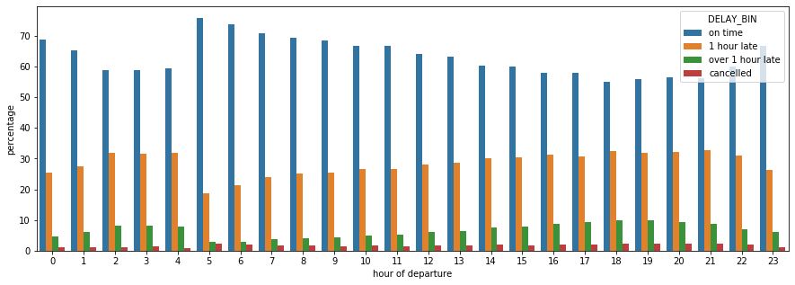

```python
plt.figure(figsize = [15, 5]);

counts = (flights2019.groupby(['DEP_HOUR'])['DELAY_BIN']
                     .value_counts(normalize=True)
                     .rename('percentage')
                     .mul(100)
                     .reset_index()
                     .sort_values('DEP_HOUR'))
p = sb.barplot(x="DEP_HOUR", y="percentage", hue="DELAY_BIN", data=counts)
plt.xlabel('hour of departure');
```

There appears to be a trend of lower percentage of on-time flights and higher percentage of delayed flights as time goes from 5am to 7pm. At that point the trend reverses, but goes down again after midnight.

Let's get a closer look at just cancelled vs. not cancelled.

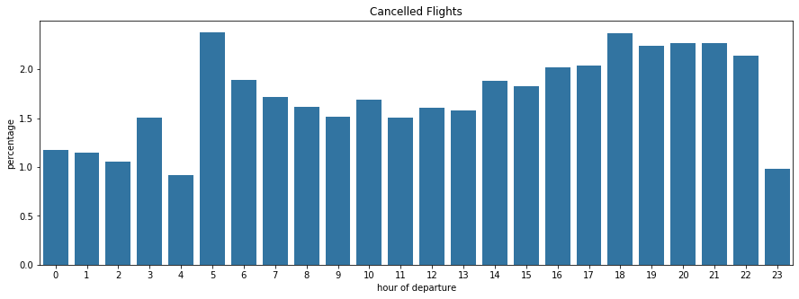

```python
plt.figure(figsize = [15, 5]);

counts = (flights2019.groupby(['DEP_HOUR'])['CANCELLED']
                     .value_counts(normalize=True)
                     .rename('percentage')
                     .mul(100)
                     .reset_index()
                     .sort_values('DEP_HOUR'))
counts_cancel = counts[counts.CANCELLED==1.0]
p = sb.barplot(x="DEP_HOUR", y="percentage", data=counts_cancel, color=default_color)
plt.xlabel('hour of departure');
plt.title('Cancelled Flights');
```

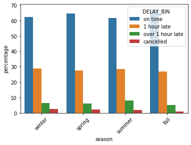

```python
counts = (flights2019.groupby(['SEASON'])['DELAY_BIN']
                     .value_counts(normalize=True)
                     .rename('percentage')
                     .mul(100)
                     .reset_index()
                     .sort_values('SEASON'))
p = sb.barplot(x="SEASON", y="percentage", hue="DELAY_BIN", data=counts, order = ['winter','spring','summer','fall'], hue_order = ['on time','1 hour late','over 1 hour late','cancelled'])
_ = plt.setp(p.get_xticklabels(), rotation=45)  # Rotate labels
plt.xlabel('season');
# plt.ylim(0,5);
```

I'm actually surprised that there aren't more delays in winter. All in all, pretty uniform.

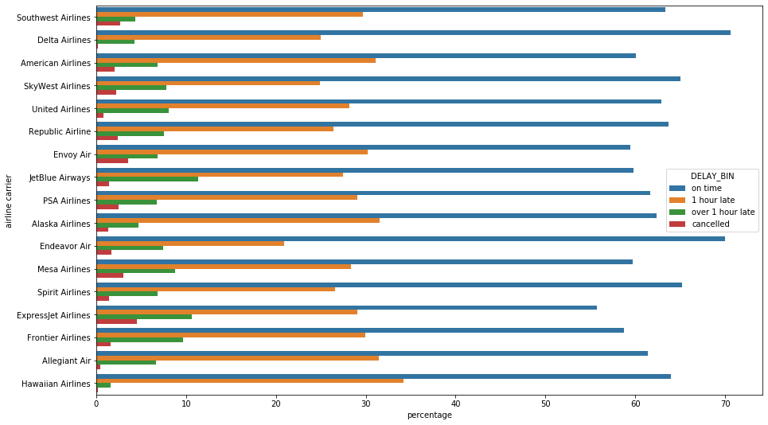

```python
airline_dict = {'9E': 'Endeavor Air', 'WN': 'Southwest Airlines', 'G4': 'Allegiant Air', 'OH': 'PSA Airlines', 'B6': 'JetBlue Airways', 'NK': 'Spirit Airlines', 'OO': 'SkyWest Airlines', 'AA': 'American Airlines', 'MQ': 'Envoy Air', 'UA': 'United Airlines', 'DL': 'Delta Airlines', 'YV': 'Mesa Airlines', 'YX': 'Republic Airline', 'AS': 'Alaska Airlines', 'F9': 'Frontier Airlines', 'HA': 'Hawaiian Airlines', 'EV': 'ExpressJet Airlines'}

carrier_order = flights2019.OP_UNIQUE_CARRIER.value_counts().index.to_list()

y_labels = [] #create an empty list to store the labels
for name in carrier_order:
    y_labels.append(airline_dict[name]) #store each label in the correct order


plt.figure(figsize = [15, 9]);

counts = (flights2019.groupby(['OP_UNIQUE_CARRIER'])['DELAY_BIN']
                     .value_counts(normalize=True)
                     .rename('percentage')
                     .mul(100)
                     .reset_index()
                     .sort_values('OP_UNIQUE_CARRIER'))
p = sb.barplot(y="OP_UNIQUE_CARRIER", x="percentage", hue="DELAY_BIN", data=counts, order = carrier_order, hue_order = ['on time','1 hour late','over 1 hour late','cancelled'], orient='h')
# _ = plt.setp(p.get_xticklabels(), rotation=90)  # Rotate labels
plt.ylabel('airline carrier');
p.set(yticklabels=y_labels);
```

Out of the top 5 busiest airlines, Delta has the highest percentage of on-time departures, and also the lowest cancellations.

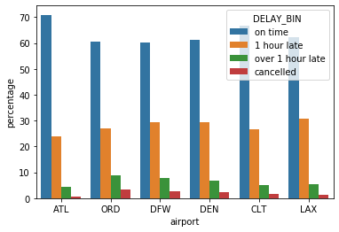

```python
airport_order = flights2019_top_airports.DEST_AIRPORT_ID.value_counts().index.to_list()

airport_x_labels = [] #create an empty list to store the labels
for name in airport_order:
    airport_x_labels.append(airport_dict[name]) #store each label in the correct order


counts = (flights2019_top_airports.groupby(['DEST_AIRPORT_ID'])['DELAY_BIN']
                     .value_counts(normalize=True)
                     .rename('percentage')
                     .mul(100)
                     .reset_index()
                     .sort_values('DEST_AIRPORT_ID'))
p = sb.barplot(x="DEST_AIRPORT_ID", y="percentage", hue="DELAY_BIN", data=counts, order = airport_order, hue_order = ['on time','1 hour late','over 1 hour late','cancelled'])
# _ = plt.setp(p.get_xticklabels(), rotation=90)  # Rotate labels
plt.xlabel('airport');
p.set(xticklabels=airport_x_labels);
```

Zoom in to get cancellation details.

```
(0, 6)
```

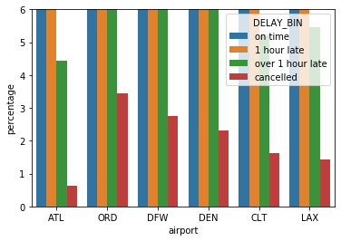

```python
airport_order = flights2019_top_airports.DEST_AIRPORT_ID.value_counts().index.to_list()

airport_x_labels = [] #create an empty list to store the labels
for name in airport_order:
    airport_x_labels.append(airport_dict[name]) #store each label in the correct order


counts = (flights2019_top_airports.groupby(['DEST_AIRPORT_ID'])['DELAY_BIN']
                     .value_counts(normalize=True)
                     .rename('percentage')
                     .mul(100)
                     .reset_index()
                     .sort_values('DEST_AIRPORT_ID'))
p = sb.barplot(x="DEST_AIRPORT_ID", y="percentage", hue="DELAY_BIN", data=counts, order = airport_order, hue_order = ['on time','1 hour late','over 1 hour late','cancelled'])
# _ = plt.setp(p.get_xticklabels(), rotation=90)  # Rotate labels
plt.xlabel('airport');
p.set(xticklabels=airport_x_labels);
plt.ylim(0,6)
```

```python
flights2019_top_airports.DEST_AIRPORT_ID.value_counts()
```

```
10397    397286
13930    338957
11298    302699
11292    250566
11057    235856
12892    221588
Name: DEST_AIRPORT_ID, dtype: int64
```

Atlanta (the busiest airport) has the highest percentage of on-time flights, as well as least percentage cancellations. ORD has the most cancellations.

Now let's look at bivariate plots of other variables besides the feature of interest.

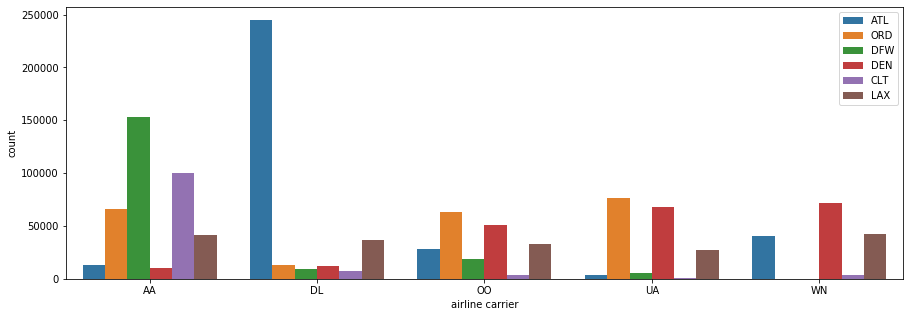

```python
# Make a new data subset of top 5 airlines and top 6 airports
flights2019_top_airlines_airports = flights2019[(flights2019.OP_UNIQUE_CARRIER.isin(top_airlines)) & (flights2019.DEST_AIRPORT_ID.isin(top_airports))]

carrier_order = flights2019_top_airlines_airports.OP_UNIQUE_CARRIER.value_counts().index.to_list()

plt.figure(figsize = [15, 5]);
x_labels = [] #create an empty list to store the labels
for name in carrier_order:
    x_labels.append(airline_dict[name]) #store each label in the correct order


airport_order = flights2019_top_airports.DEST_AIRPORT_ID.value_counts().index.to_list()

hue_labels = [] #create an empty list to store the labels
for name in airport_order:
    hue_labels.append(airport_dict[name]) #store each label in the correct order

ax = sb.countplot(data=flights2019_top_airlines_airports,x='OP_UNIQUE_CARRIER',hue='DEST_AIRPORT_ID', order=carrier_order, hue_order = airport_order)
p.set(xticklabels=x_labels);
plt.xlabel('airline carrier');
ax.legend(labels=hue_labels);
```

This just tells me that Delta probably has a hub in Atlanta, and Southwest doesn't fly into O'Hare or Dallas airport at all.

Now I'd like to plot departure time and destination airport. To keep it reasonable, I'm plotting only time of day.

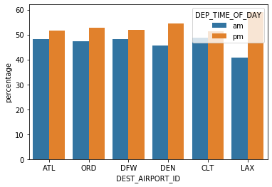

```python
flights2019_top_airports = flights2019[flights2019.DEST_AIRPORT_ID.isin(top_airports)] # Redo to get DEP_TIME_OF_DAY

counts = (flights2019_top_airports.groupby(['DEST_AIRPORT_ID'])['DEP_TIME_OF_DAY']
                     .value_counts(normalize=True)
                     .rename('percentage')
                     .mul(100)
                     .reset_index()
                     .sort_values('DEST_AIRPORT_ID'))
p = sb.barplot(x="DEST_AIRPORT_ID", y="percentage", hue="DEP_TIME_OF_DAY", data=counts, order = airport_order, hue_order = ['am','pm'])
p.set(xticklabels=airport_x_labels);
```

LAX has more flights coming in that departed in the afternoon, for whatever reason. I would have thought that, since it's on the west coast with the earliest time zone, more flights would depart earlier.

Now look at time of day and day of week.

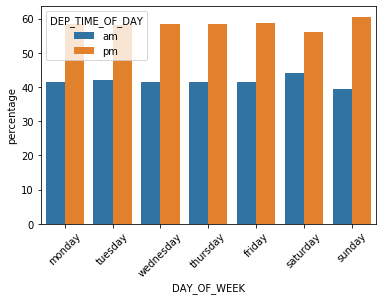

```python
counts = (flights2019.groupby(['DAY_OF_WEEK'])['DEP_TIME_OF_DAY']
                     .value_counts(normalize=True)
                     .rename('percentage')
                     .mul(100)
                     .reset_index()
                     .sort_values('DAY_OF_WEEK'))
p = sb.barplot(x="DAY_OF_WEEK", y="percentage", hue="DEP_TIME_OF_DAY", data=counts, hue_order = ['am','pm'])
p.set(xticklabels=['monday','tuesday','wednesday','thursday','friday','saturday','sunday']);
_ = plt.setp(p.get_xticklabels(), rotation=45)
```

Everthing seems to be pretty uniformly distributed among the days of the week.

```python
# Make a data subset for only the cancelled flights
flights2019_cancelled = flights2019[flights2019.CANCELLED==1]
flights2019_cancelled.shape
```

```
(138807, 24)
```

Now look at how flight cancellation causes are distributed among the seasons.

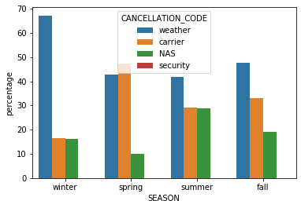

```python
flights2019_cancelled['CANCELLATION_CODE'] = flights2019_cancelled['CANCELLATION_CODE'].replace(['A','B','C','D'], ['carrier','weather','NAS','security'])

counts = (flights2019_cancelled.groupby(['SEASON'])['CANCELLATION_CODE']
                     .value_counts(normalize=True)
                     .rename('percentage')
                     .mul(100)
                     .reset_index()
                     .sort_values('SEASON'))
cancel_order = flights2019_cancelled.CANCELLATION_CODE.value_counts().index
p = sb.barplot(x="SEASON", y="percentage", hue="CANCELLATION_CODE", data=counts, order = ['winter','spring','summer','fall'], hue_order = cancel_order)
```

```python
counts
```

|  | SEASON | CANCELLATION_CODE | percentage |
| --- | --- | --- | --- |
| 0 | fall | weather | 47.815159 |
| 1 | fall | carrier | 32.965971 |
| 2 | fall | NAS | 19.218871 |
| 3 | spring | carrier | 47.199790 |
| 4 | spring | weather | 42.810697 |
| 5 | spring | NAS | 9.984268 |
| 6 | spring | security | 0.005244 |
| 7 | summer | weather | 41.852999 |
| 8 | summer | carrier | 29.204701 |
| 9 | summer | NAS | 28.917176 |
| 10 | summer | security | 0.025124 |
| 11 | winter | weather | 67.233028 |
| 12 | winter | carrier | 16.502752 |
| 13 | winter | NAS | 16.256881 |
| 14 | winter | security | 0.007339 |

As expected, winter has the highest percentage of cancellations due to weather. However, both summer and fall cancellations are most often due to weather as well. Security is almost never a cause of cancellation.

### Did you observe any interesting relationships between the other features (not the main feature(s) of interest)?

The plot with season and cancellation cause is insightful. As expected, winter has the highest percentage of cancellations due to weather. However, both summer and fall cancellations are most often due to weather as well. Security is almost never a cause of cancellation. And all 4 seasons have a slightly different distribution between the 4 causes.

## Multivariate Exploration

The last exploration of season vs. cancellation cause was interesting. So, I'd like to add another variable I think may show something interesting. I'll add airport, which should be correlated with cancellations due to weather at least, since some airports are in areas that snow, and others get almost no snow.

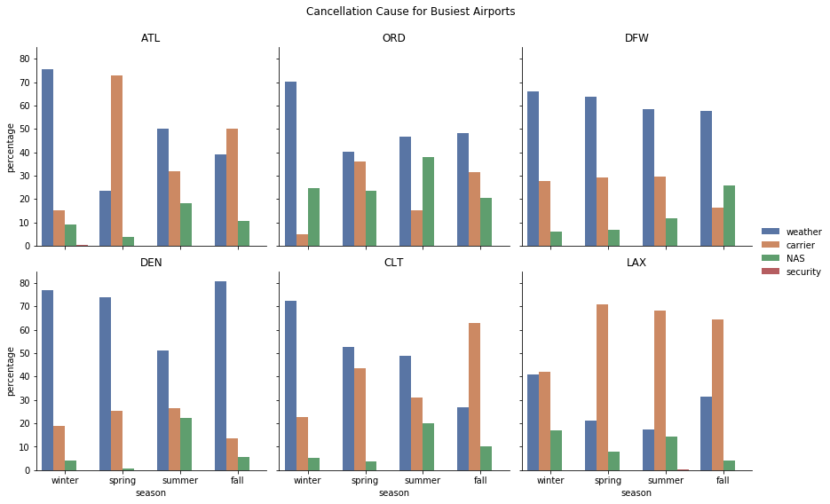

```python
flights2019_top_airports_cancelled = flights2019[(flights2019.DEST_AIRPORT_ID.isin(top_airports)) & (flights2019.CANCELLED==1)] # Redo for cancelled flights
flights2019_top_airports_cancelled['CANCELLATION_CODE'] = flights2019_top_airports_cancelled['CANCELLATION_CODE'].replace(['A','B','C','D'], ['carrier','weather','NAS','security'])


counts = (flights2019_top_airports_cancelled.groupby(['DEST_AIRPORT_ID','SEASON'])['CANCELLATION_CODE']
                     .value_counts(normalize=True)
                     .rename('percentage')
                     .mul(100)
                     .reset_index()
                     .sort_values(['DEST_AIRPORT_ID','SEASON']))


g = sb.FacetGrid(counts, col='DEST_AIRPORT_ID', col_wrap=3, height=4, col_order = airport_order);
g.map(sb.barplot,'SEASON','percentage','CANCELLATION_CODE', order = ['winter','spring','summer','fall'], hue_order=cancel_order, palette="deep").add_legend();

axes = g.axes.flatten();
axes[0].set_title("ATL");
axes[1].set_title("ORD");
axes[2].set_title("DFW");
axes[3].set_title("DEN");
axes[4].set_title("CLT");
axes[5].set_title("LAX");

plt.subplots_adjust(top=0.9)
g.fig.suptitle('Cancellation Cause for Busiest Airports');
axes[3].set_xlabel("season");
axes[4].set_xlabel("season");
axes[5].set_xlabel("season");
```

These results are interesting, because I expected the airports in cities with colder seasons to have delays due to snowstorms. This hypothesis is consistent with results from LAX, but not the others. One possible explanation is that all airports can be affected by snowstorms in only certain cities. For example, since Atlanta is a big airline hub, it's greatly affected by weather in colder cities. Another explanation is that of course 'weather' doesn't have to mean snowstorms. Hurricanes, although much less common, would also severely disrupt flights in large regions, as would thunderstorms/hail. Still, LAX is different from all these other airports in that weather is never the main cause of delay, no matter which season. At ORD, DFW, and DEN, weather is the leading cause of cancellation for all seasons. Additionally, the only times that cancellations due to NAS were more common than carrier cancellations were at ORD in summer and winter, as well as DFW in the fall. Lastly, cancellations due to security are an insigificant percentage of cancellations across the board.

```python
airport_dict
```

```
{10397: 'ATL',
 13930: 'ORD',
 11298: 'DFW',
 11292: 'DEN',
 11057: 'CLT',
 12892: 'LAX'}
```

Now do something similar except instead of cancellation cause, look at delay.

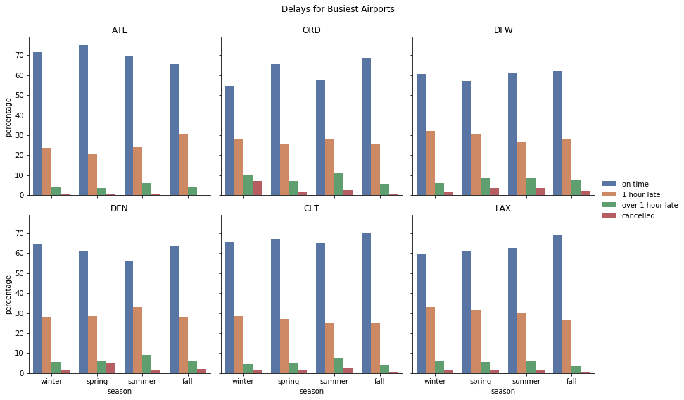

```python
counts = (flights2019_top_airports.groupby(['DEST_AIRPORT_ID','SEASON'])['DELAY_BIN']
                     .value_counts(normalize=True)
                     .rename('percentage')
                     .mul(100)
                     .reset_index()
                     .sort_values(['DEST_AIRPORT_ID','SEASON']))

g = sb.FacetGrid(counts, col='DEST_AIRPORT_ID', col_wrap=3, height=4, col_order = airport_order);
g.map(sb.barplot,'SEASON','percentage','DELAY_BIN', order = ['winter','spring','summer','fall'], hue_order=['on time','1 hour late','over 1 hour late','cancelled'], palette="deep").add_legend();

axes = g.axes.flatten();
axes[0].set_title("ATL");
axes[1].set_title("ORD");
axes[2].set_title("DFW");
axes[3].set_title("DEN");
axes[4].set_title("CLT");
axes[5].set_title("LAX");

plt.subplots_adjust(top=0.9)
g.fig.suptitle('Delays for Busiest Airports');
# plt.xlabel('season')
axes[3].set_xlabel("season");
axes[4].set_xlabel("season");
axes[5].set_xlabel("season");
```

There doesn't seem to be any major differences across the different airports. The worst performance looks like it was from ORD during winter (makes sense if it was due to weather). The best appears to be from ATL in the spring. But neither of these are worse or better by a large margin.

Lastly, let's look at a plot with 4 variables, adding time of day to the plot with season, airport, and cancellation cause.

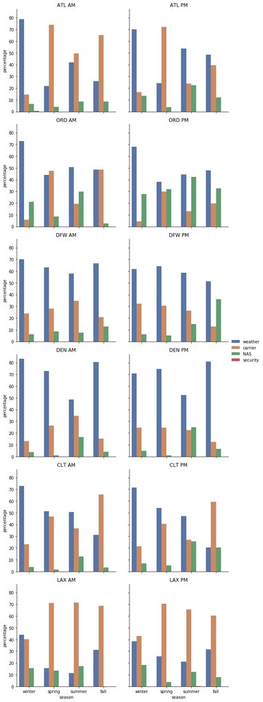

```python
counts = (flights2019_top_airports_cancelled.groupby(['DEST_AIRPORT_ID','DEP_TIME_OF_DAY','SEASON'])['CANCELLATION_CODE']
                     .value_counts(normalize=True)
                     .rename('percentage')
                     .mul(100)
                     .reset_index()
                     .sort_values(['DEST_AIRPORT_ID','DEP_TIME_OF_DAY','SEASON']))

g = sb.FacetGrid(counts, row='DEST_AIRPORT_ID', col='DEP_TIME_OF_DAY', height=4, row_order = airport_order);
g.map(sb.barplot,'SEASON','percentage','CANCELLATION_CODE', order = ['winter','spring','summer','fall'], hue_order=cancel_order, palette="deep").add_legend();

axes = g.axes.flatten();

axes[0].set_title("ATL AM");
axes[1].set_title("ATL PM");
axes[2].set_title("ORD AM");
axes[3].set_title("ORD PM");
axes[4].set_title("DFW AM");
axes[5].set_title("DFW PM");
axes[6].set_title("DEN AM");
axes[7].set_title("DEN PM");
axes[8].set_title("CLT AM");
axes[9].set_title("CLT PM");
axes[10].set_title("LAX AM");
axes[11].set_title("LAX PM");

axes[10].set_xlabel("season");
axes[11].set_xlabel("season");
```

At most aiports, across all seasons, National Air System (NAS) cancellations seems to be responsible for a greater number of cancellations for flights that departed in the afternoon than in the morning. The exception to this trend was LAX.

### Talk about some of the relationships you observed in this part of the investigation. Were there features that strengthened each other in terms of looking at your feature(s) of interest?

Adding in the airport to the bivariate plot with season and cancellation cause, we can see that there are definitely differences in the cancellation causes between different airports. Weather was a more prominent cause of cancellation at some airports than others. Also, the relative percentage of flights affected by weather, carrier, and NAS-related cancellations varied widely between different airports. Adding in airport information helped show where the prominent weather cancellations could be coming from. The last plot with 4 variables where I added in departure time of day did not strengthen any findings, but showed how NAS cancellations tended to increase. It also solidified that LAX seems to be an outlier among the other 5 airports.

### Were there any interesting or surprising interactions between features?

These results are interesting, because I expected the airports in cities with colder seasons to have delays due to snowstorms. This hypothesis is consistent with results from LAX, but not the others. One possible explanation is that all airports can be affected by snowstorms in only certain cities. For example, since Atlanta is a big airline hub, it's greatly affected by weather in colder cities. Another explanation is that of course 'weather' doesn't have to mean snowstorms. Still, LAX is different from all these other airports in that weather is never the main cause of delay.

```python
flights2019.to_csv("flights2019_cleaned.csv")
```